# Reproduceable Reaearch Project 1

## 7. Histogram of the total number of steps taken each day after missing values are imputed

Prepare the aggregated Total Steps per Date data set by using filled dataset.

```r
totalStepsPerDate_fill <- aggregate(activity$steps ~ activity$date, FUN=sum )
colnames(totalStepsPerDate_fill)<- c("Date", "Steps")
```

Show full picture histogram of the total number of steps taken each day after missing values are imputed

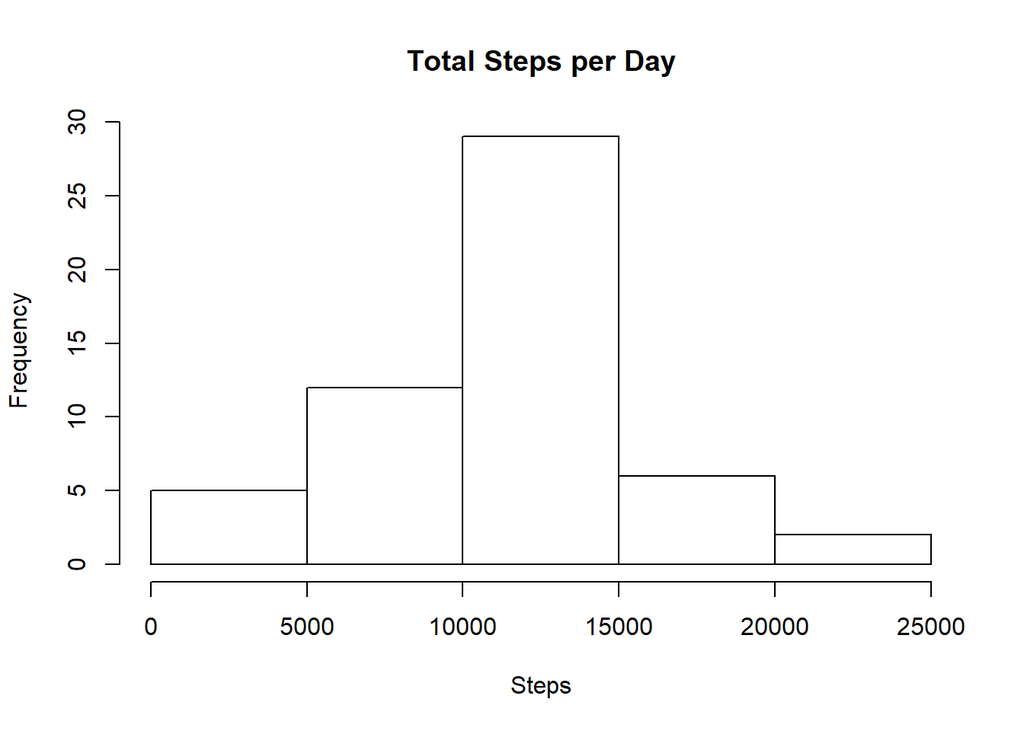

```r
revMeanSteps <- mean(totalStepsPerDate_fill$Steps)
revMedianSteps <- median(totalStepsPerDate_fill$Steps)
```

The original **Mean and Median** number of steps taken each day are 1.076618910^{4} and 10765. Whereas the revised **Mean and Median** number of steps taken each day are 1.076618910^{4} and 1.076559410^{4}. So the mean value remains the same as prior to imputation, while the median value increased slightly.

## 8. Panel plot comparing the average number of steps taken per 5-minute interval across weekdays and weekends

Prepare weekend and weekday data to use in plot.

```r
## Add one more day column to insert weekned and weekday data.
activity$day <- ifelse(weekdays(as.Date(activity$date)) == "Saturday" | weekdays(as.Date(activity$date)) == "Sunday", "weekend", "weekday")

# Calculate average steps per interval for weekends
avgStepsPerInterval_weekend <- aggregate(as.integer(activity[activity$day == "weekend",1]) ~ activity[activity$day == "weekend",3],FUN=mean)
colnames(avgStepsPerInterval_weekend) <- c("Interval","AvgSteps")

# Calculate average steps per interval for weekdays
avgStepsPerInterval_weekday <- aggregate(as.integer(activity[activity$day == "weekday",1]) ~ activity[activity$day == "weekday",3],FUN=mean)
colnames(avgStepsPerInterval_weekday) <- c("Interval","AvgSteps")
```

Show Panel plot comparing the average number of steps taken per 5-minute interval across weekdays and weekends

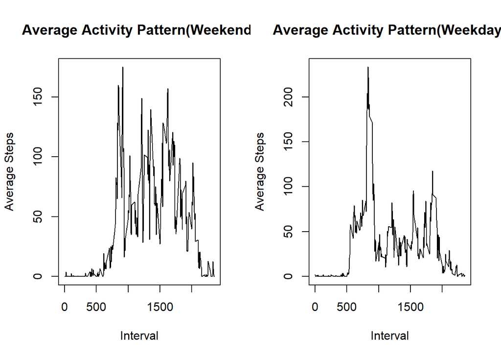